# Problem set 1

# Details

# Task 1

# Task 2

## Life expectancy in 2007

```r
# Notice the warning=FALSE and message=FALSE in the chunk options. R spits out
# a lot of messages when you load tidyverse and we don't want those in the
# final document.

library(tidyverse)  # This loads ggplot2, dplyr, and other packages you'll need
library(gapminder)  # This loads the gapminder data
```

Let’s first look at the first few rows of data:

```r
head(gapminder)
```

```
## # A tibble: 6 x 6
##   country     continent  year lifeExp      pop gdpPercap
##   <fct>       <fct>     <int>   <dbl>    <int>     <dbl>
## 1 Afghanistan Asia       1952    28.8  8425333      779.
## 2 Afghanistan Asia       1957    30.3  9240934      821.
## 3 Afghanistan Asia       1962    32.0 10267083      853.
## 4 Afghanistan Asia       1967    34.0 11537966      836.
## 5 Afghanistan Asia       1972    36.1 13079460      740.
## 6 Afghanistan Asia       1977    38.4 14880372      786.
```

Right now, the `gapminder` data frame contains rows for all years for all countries. We want to only look at 2007, so we create a new data frame that filters only rows for 2007.

Note how there’s a weird sequence of characters: `%>%`. This is called a *pipe* and lets you chain functions together. We could have also written this as `gapminder_2007 <- filter(gapminder, year == 2007)`.

```r
gapminder_2007 <- gapminder %>%
  filter(year == 2007)

head(gapminder_2007)
```

```
## # A tibble: 6 x 6
##   country     continent  year lifeExp      pop gdpPercap
##   <fct>       <fct>     <int>   <dbl>    <int>     <dbl>
## 1 Afghanistan Asia       2007    43.8 31889923      975.
## 2 Albania     Europe     2007    76.4  3600523     5937.
## 3 Algeria     Africa     2007    72.3 33333216     6223.
## 4 Angola      Africa     2007    42.7 12420476     4797.
## 5 Argentina   Americas   2007    75.3 40301927    12779.
## 6 Australia   Oceania    2007    81.2 20434176    34435.
```

Now we can plot a histogram of 2007 life expectancies with the default settings:

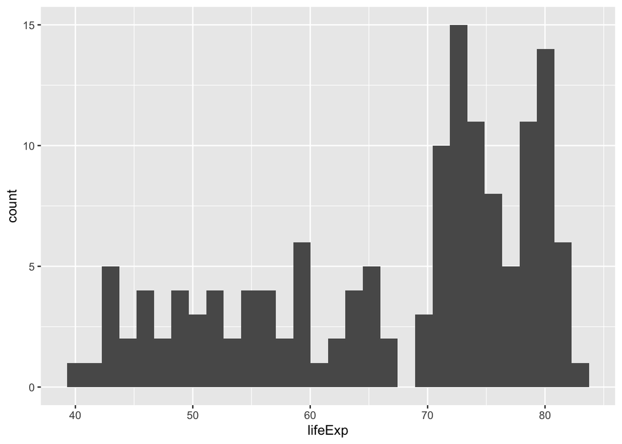

```r
ggplot(data = gapminder_2007,
       mapping = aes(x = lifeExp)) +
  geom_histogram()
```

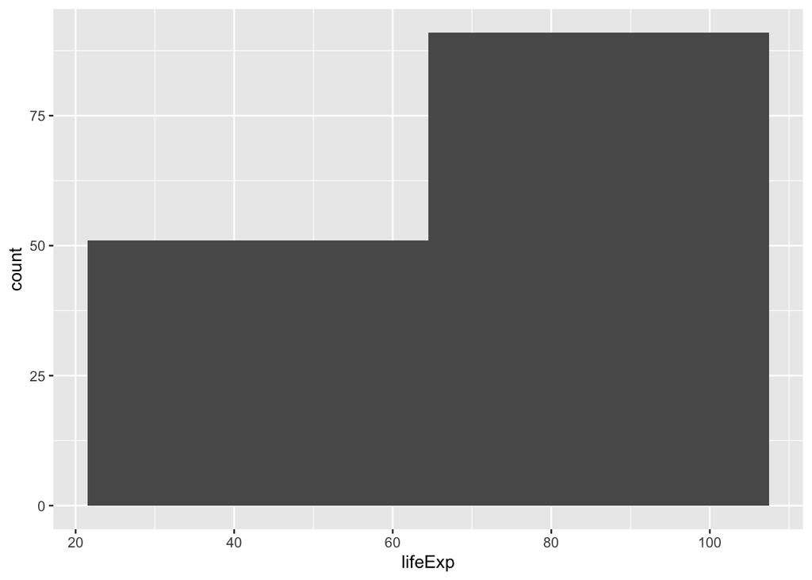

```r
ggplot(data = gapminder_2007,
       mapping = aes(x = lifeExp)) +
  geom_histogram(bins = 2)
```

## Average life expectancy in 2007 by continent

We’re also interested in the differences of life expectancy across continents. First, we can group all rows by continent and calculate the mean

This is where the `%>%` function is actually super useful. Remember that it lets you chain functions together—this means we can read these commands as a set of instructions: take the `gapminder` data frame, filter it, group it by continent, and summarize each group by calculating the mean. Without using the `%>%`, we could write this same chain like this: `summarize(group_by(filter(gapminder, year == 2007), continent), avg_life_exp = mean(lifeExp))`. But that’s *awful* and impossible to read and full of parentheses that can easily be mismatched.

```r
gapminder_cont_2007 <- gapminder %>%
  filter(year == 2007) %>%
  group_by(continent) %>%
  summarize(avg_life_exp = mean(lifeExp))

head(gapminder_cont_2007)
```

```
## # A tibble: 5 x 2
##   continent avg_life_exp
##   <fct>            <dbl>
## 1 Africa            54.8
## 2 Americas          73.6
## 3 Asia              70.7
## 4 Europe            77.6
## 5 Oceania           80.7
```

Let’s plot these averages as a bar chart:

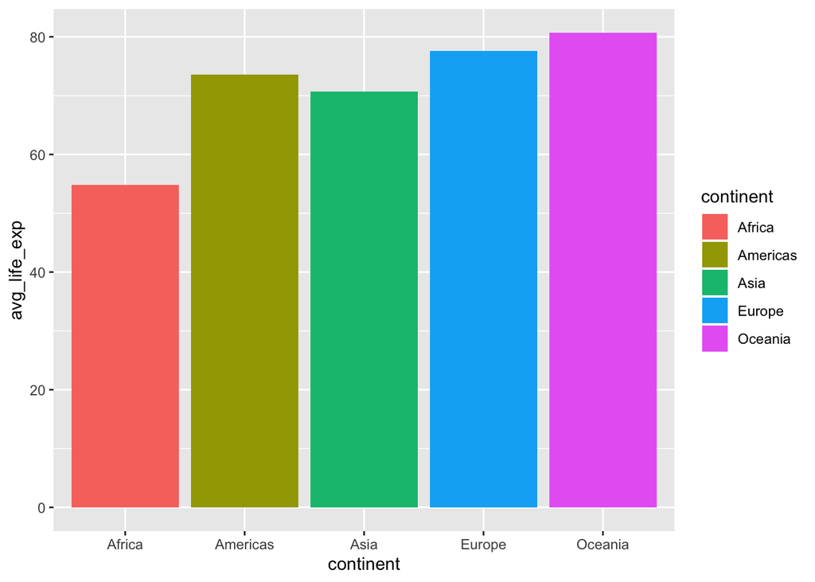

```r
ggplot(data = gapminder_cont_2007,
       mapping = aes(x = continent, y = avg_life_exp, fill = continent)) +
  geom_col()
```

Then, let’s plot them as density distributions. We don’t need to use the summarized data frame for this, just the original filtered `gapminder_2007` data frame:

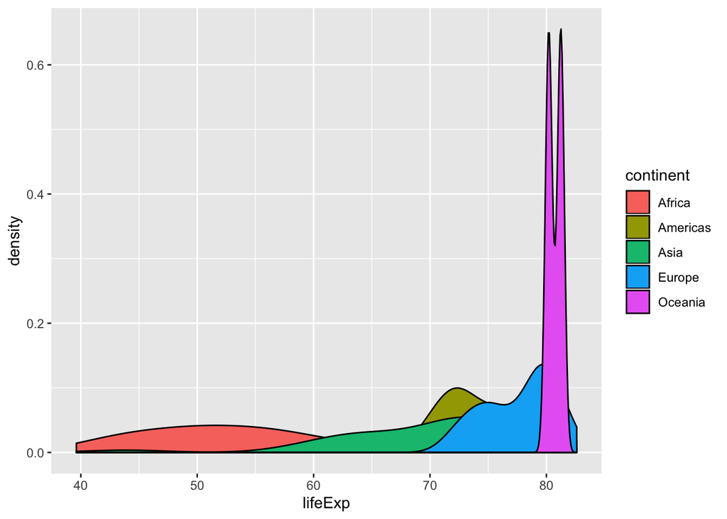

```r
ggplot(data = gapminder_2007,
       mapping = aes(x = lifeExp, fill = continent)) +
  geom_density()
```

Now let’s plot life expectancies as violin charts. These are the density distributions turned sideways:

[figure not shown]

```r
ggplot(data = gapminder_2007,
       mapping = aes(x = continent, y = lifeExp, fill = continent)) +
  geom_violin()
```

Finally, we can add actual points of data for each country to the violin chart:

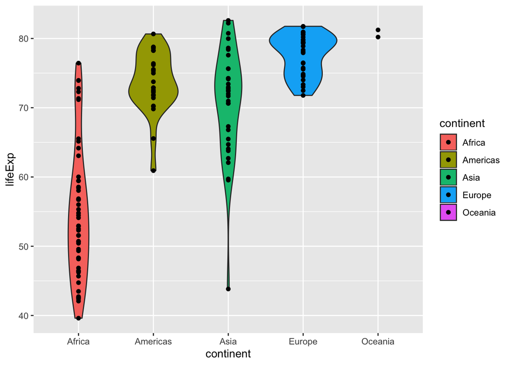

```r
ggplot(data = gapminder_2007,
       mapping = aes(x = continent, y = lifeExp, fill = continent)) +
  geom_violin() +
  geom_point()
```

# Task 3: R and ggplot

```r
# Technically you don't need to run this because we loaded tidyverse earlier in Task 2
library(tidyverse)
```

## 3.2.4

**1: Run `ggplot(data = mpg)`. What do you see?**

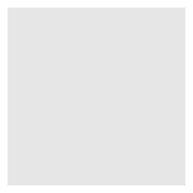

```r
ggplot(data = mpg)
```

(Notice how I used `fig.width` and `fig.height` in the chunk options. You can click on the little gear icon in the far left of the chunk to change other options.)

**2: How many rows are in `mpg`? How many columns?**

```r
nrow(mpg)
```

```
## [1] 234
```

```r
ncol(mpg)
```

```
## [1] 11
```

```r
# Or
dim(mpg)
```

```
## [1] 234  11
```

```r
# Or
mpg
```

```
## # A tibble: 234 x 11
##    manufacturer model displ  year   cyl trans drv     cty   hwy fl    class
##    <chr>        <chr> <dbl> <int> <int> <chr> <chr> <int> <int> <chr> <chr>
##  1 audi         a4      1.8  1999     4 auto… f        18    29 p     comp…
##  2 audi         a4      1.8  1999     4 manu… f        21    29 p     comp…
##  3 audi         a4      2    2008     4 manu… f        20    31 p     comp…
##  4 audi         a4      2    2008     4 auto… f        21    30 p     comp…
##  5 audi         a4      2.8  1999     6 auto… f        16    26 p     comp…
##  6 audi         a4      2.8  1999     6 manu… f        18    26 p     comp…
##  7 audi         a4      3.1  2008     6 auto… f        18    27 p     comp…
##  8 audi         a4 q…   1.8  1999     4 manu… 4        18    26 p     comp…
##  9 audi         a4 q…   1.8  1999     4 auto… 4        16    25 p     comp…
## 10 audi         a4 q…   2    2008     4 manu… 4        20    28 p     comp…
## # … with 224 more rows
```

**3: What does the `drv` variable describe? Read the help for `?mpg` to find out.**

**4: Make a scatterplot of `hwy` vs `cyl`.**

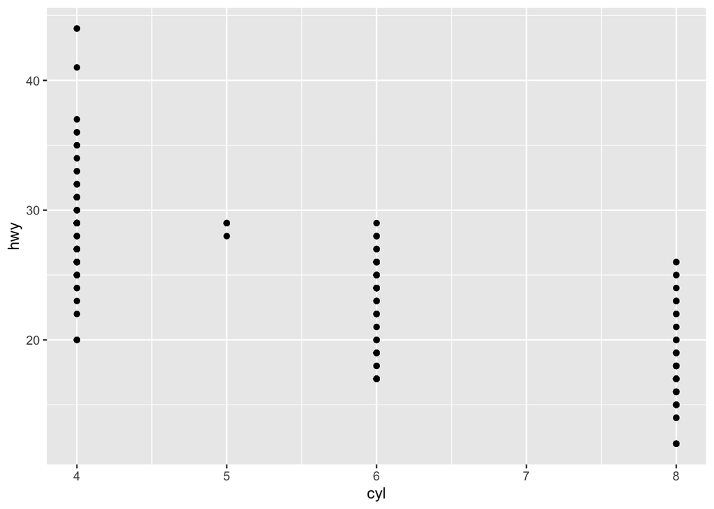

```r
ggplot(data = mpg) +
  geom_point(mapping = aes(x = cyl, y = hwy))
```

**5: What happens if you make a scatterplot of `class` vs `drv`? Why is the plot not useful?**

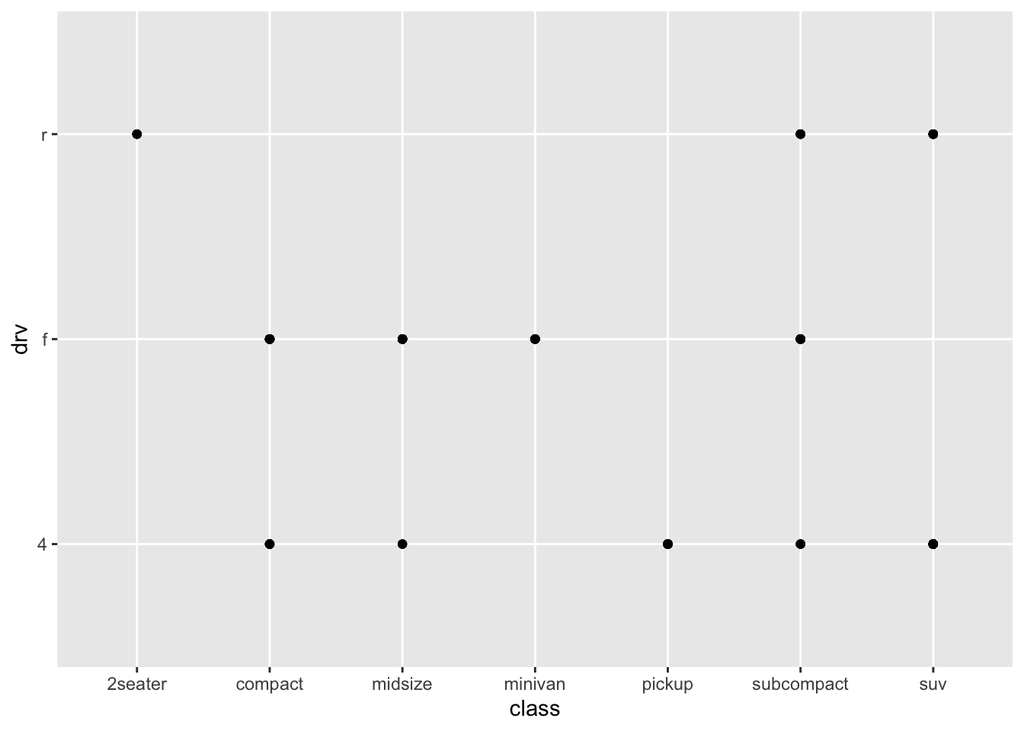

```r
ggplot(data = mpg) +
  geom_point(mapping = aes(x = class, y = drv))
```